# Fungi_k / Ascomycota_p ASV 서열 구조

maxEE22 Cutadapt–ITSxpress exact-containment pairwise alignment

2026-10-15

# 1 1. 분석 대상

이 보고서는 `Fungi_k`와 `Ascomycota_p`로만 분류된 Cutadapt ASV를 대상으로 함. 각 Cutadapt ASV 내부에서 exact match되는 ITSxpress ASV를 찾아 다음처럼 직접 표시함.

```
Cutadapt   [left external sequence][exact ITSxpress sequence][right external sequence]
ITSxpress  -------------------------[exact ITSxpress sequence]-------------------------
Match                               |||||||||||||||||||||||||||
```

여기서 주황색 구간은 두 방법에서 염기가 완전히 동일한 부분이며, 회색 dash는 ITSxpress 결과에 존재하지 않는 Cutadapt 외부 서열임.

```r
asv_metrics <- read_csv(
  "Results/01_Preprocessing/05a_unresolved_taxa_ASV_metrics.csv",
  show_col_types = FALSE
)
all_matches <- read_csv(
  "Results/01_Preprocessing/05m_all_exact_containment_pairs.csv",
  show_col_types = FALSE
)

sequence_info <- asv_metrics |>
  select(Method, FeatureID, Sequence, Raw_Taxonomy)

cut_info <- sequence_info |>
  filter(Method == "Cutadapt") |>
  transmute(
    Cutadapt_FeatureID = FeatureID,
    Cutadapt_Sequence = Sequence,
    Cutadapt_Raw_Taxonomy = Raw_Taxonomy
  )

its_info <- sequence_info |>
  filter(Method == "ITSxpress") |>
  transmute(
    ITSxpress_FeatureID = FeatureID,
    ITSxpress_Sequence = Sequence,
    ITSxpress_Raw_Taxonomy = Raw_Taxonomy
  )

focus_pairs <- all_matches |>
  filter(
    Cutadapt_Group %in% c("Fungi_k", "Ascomycota_p"),
    Match_Type == "ITSxpress_within_Cutadapt"
  ) |>
  left_join(cut_info, by = "Cutadapt_FeatureID") |>
  left_join(its_info, by = "ITSxpress_FeatureID") |>
  mutate(
    ITS_Start = str_locate(Cutadapt_Sequence, fixed(ITSxpress_Sequence))[, "start"],
    ITS_End = ITS_Start + ITSxpress_Length - 1L,
    Left_Flank_bp = ITS_Start - 1L,
    Right_Flank_bp = Cutadapt_Length - ITS_End,
    Total_Flank_bp = Left_Flank_bp + Right_Flank_bp
  ) |>
  arrange(factor(Cutadapt_Group, levels = c("Fungi_k", "Ascomycota_p")),
          desc(Cutadapt_Total_Reads)) |>
  group_by(Cutadapt_Group) |>
  mutate(Group_Pair = row_number()) |>
  ungroup() |>
  mutate(Pair_ID = if_else(
    Cutadapt_Group == "Fungi_k",
    sprintf("F%02d", Group_Pair),
    sprintf("A%02d", Group_Pair)
  ))

stopifnot(nrow(focus_pairs) == 28L, all(!is.na(focus_pairs$ITS_Start)))
write_csv(focus_pairs, file.path(results_dir, "01_focused_exact_containment_pairs.csv"))
```

# 2 2. Flank/core 길이 구조

```r
structure_summary <- focus_pairs |>
  group_by(Cutadapt_Group) |>
  summarise(
    N_ASV_pairs = n(),
    Median_Cutadapt_length = median(Cutadapt_Length),
    Median_ITSxpress_length = median(ITSxpress_Length),
    Median_left_flank = median(Left_Flank_bp),
    Median_right_flank = median(Right_Flank_bp),
    Median_total_flank = median(Total_Flank_bp),
    Min_total_flank = min(Total_Flank_bp),
    Max_total_flank = max(Total_Flank_bp),
    .groups = "drop"
  )

datatable_basic(structure_summary, 10)
```

| Cutadapt_Group | N_ASV_pairs | Median_Cutadapt_length | Median_ITSxpress_length | Median_left_flank | Median_right_flank | Median_total_flank | Min_total_flank | Max_total_flank |
| --- | --- | --- | --- | --- | --- | --- | --- | --- |
| Ascomycota_p | 20 | 301 | 153 | 108 | 40 | 148 | 144 | 149 |
| Fungi_k | 8 | 367 | 223 | 108 | 39 | 147.5 | 144 | 168 |

```r
write_csv(structure_summary, file.path(results_dir, "02_flank_core_length_summary.csv"))
```

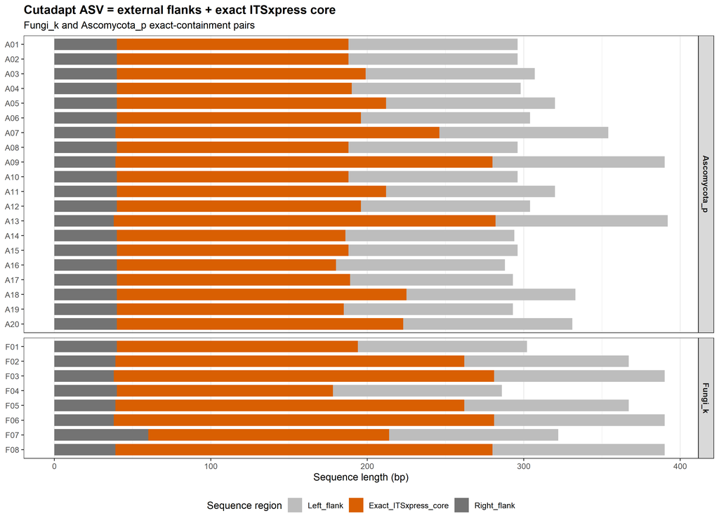

```r
structure_long <- focus_pairs |>
  transmute(
    Pair_ID, Cutadapt_Group, Cutadapt_Total_Reads,
    Left_flank = Left_Flank_bp,
    Exact_ITSxpress_core = ITSxpress_Length,
    Right_flank = Right_Flank_bp
  ) |>
  pivot_longer(c(Left_flank, Exact_ITSxpress_core, Right_flank),
               names_to = "Region", values_to = "Length_bp") |>
  mutate(
    Region = factor(Region,
                    levels = c("Left_flank", "Exact_ITSxpress_core", "Right_flank")),
    Pair_ID = factor(Pair_ID, levels = rev(focus_pairs$Pair_ID))
  )

structure_plot <- ggplot(structure_long,
                         aes(Pair_ID, Length_bp, fill = Region)) +
  geom_col(width = 0.78) +
  coord_flip() +
  facet_grid(Cutadapt_Group ~ ., scales = "free_y", space = "free_y") +
  scale_fill_manual(values = c(
    Left_flank = "#BDBDBD",
    Exact_ITSxpress_core = "#D95F02",
    Right_flank = "#737373"
  )) +
  labs(
    title = "Cutadapt ASV = external flanks + exact ITSxpress core",
    subtitle = "Fungi_k and Ascomycota_p exact-containment pairs",
    x = NULL, y = "Sequence length (bp)", fill = "Sequence region"
  ) +
  theme_bw(base_size = 11) +
  theme(panel.grid.major.y = element_blank(), legend.position = "bottom",
        strip.text = element_text(face = "bold"),
        plot.title = element_text(face = "bold"))

ggsave(file.path(results_dir, "03_flank_core_structure.png"),
       structure_plot, width = 11, height = 8, dpi = 220, bg = "white")
structure_plot
```

# 3 3. 실제 염기서열 pairwise alignment

각 pair를 75 bp 단위로 나누어 표시함. 아래에는 ASV 이름보다 실제 A/C/G/T 배열이 중심이 되도록 구성함.

## 3.1 3.1 Fungi_k — 8 pairs

**F01 · Fungi_k** Cutadapt 302 bp · ITSxpress 154 bp · left/right flank 108/40 bp · Cutadapt reads 25,439

```
      1-75
Cutadapt   GAAATGCGATAAGTAATGTGAATTGCAGAATTCAGTGAATCATCGAATCTTTGAACGCACATTGCGCCCCTTGGT
ITSxpress  ---------------------------------------------------------------------------
Match

     76-150
Cutadapt   ATTCCGAGGGGCATGCCTGTTCGAGCGTCATTACACCACTCAAGCTATGCTTGGTATTGGGTGCCGTCCTTAGTT
ITSxpress  ---------------------------------CACCACTCAAGCTATGCTTGGTATTGGGTGCCGTCCTTAGTT
Match                                       ||||||||||||||||||||||||||||||||||||||||||

    151-225
Cutadapt   GGGCGCGCCTTAAAGACCTCGGCGAGGCCTCACCGGCTTTAGGCGTAGTAGAATTTATTCGAACGTCTGTCAAAG
ITSxpress  GGGCGCGCCTTAAAGACCTCGGCGAGGCCTCACCGGCTTTAGGCGTAGTAGAATTTATTCGAACGTCTGTCAAAG
Match      |||||||||||||||||||||||||||||||||||||||||||||||||||||||||||||||||||||||||||

    226-300
Cutadapt   GAGAGGACTTCTGCCGACTGAAACCTTTATTTTTCTAGGTTGACCTCGGATCAGGTAGGGATACCCGCTGAACTT
ITSxpress  GAGAGGACTTCTGCCGACTGAAACCTTTATTTTTCTA--------------------------------------
Match      |||||||||||||||||||||||||||||||||||||

    301-302
Cutadapt   AA
ITSxpress  --
Match
```

**F02 · Fungi_k** Cutadapt 367 bp · ITSxpress 223 bp · left/right flank 105/39 bp · Cutadapt reads 862

```
      1-75
Cutadapt   GAAGTGCGATAAGCAATGCGAATTGCAGAATTCCGCGAATCATCAGATCTTTGAACGCAAATGGCGCCAGAGGGA
ITSxpress  ---------------------------------------------------------------------------
Match

     76-150
Cutadapt   TATCCTTTTGGCATGTCTGTTTCAGTGTCTGAGAGGTTTCACCTTTATCTTAATGTGATTGACTCGTGTTTTTGG
ITSxpress  ------------------------------GAGAGGTTTCACCTTTATCTTAATGTGATTGACTCGTGTTTTTGG
Match                                    |||||||||||||||||||||||||||||||||||||||||||||

    151-225
Cutadapt   GCAACCGATCGCACAGTCTCTCATGAAAGATGCGCGAGTGGATCTTTCGGTCCAATGAAGTGGTCACATCACTCG
ITSxpress  GCAACCGATCGCACAGTCTCTCATGAAAGATGCGCGAGTGGATCTTTCGGTCCAATGAAGTGGTCACATCACTCG
Match      |||||||||||||||||||||||||||||||||||||||||||||||||||||||||||||||||||||||||||

    226-300
Cutadapt   TATGTGATTTCATTGGAAGCACCGAATTATCCGCTACACTCGCGGTTCCTGTGTAACGGCATCCTCCTCAAAACG
ITSxpress  TATGTGATTTCATTGGAAGCACCGAATTATCCGCTACACTCGCGGTTCCTGTGTAACGGCATCCTCCTCAAAACG
Match      |||||||||||||||||||||||||||||||||||||||||||||||||||||||||||||||||||||||||||

    301-367
Cutadapt   GGACGCTGTTATTACTAACTCTCTACACCCTGCATCTGAGACAGGCAAGATCACCCGCTGAACTTAA
ITSxpress  GGACGCTGTTATTACTAACTCTCTACAC---------------------------------------
Match      ||||||||||||||||||||||||||||
```

**F03 · Fungi_k** Cutadapt 390 bp · ITSxpress 243 bp · left/right flank 109/38 bp · Cutadapt reads 525

```
      1-75
Cutadapt   GAAATGCGACACTTGGTGTGAATTGCAGAATCCCGTGAACCATCGAGTCTTTGAATGCAAGTTGCGCTCGAGGCC
ITSxpress  ---------------------------------------------------------------------------
Match

     76-150
Cutadapt   ATTAGGTTGAGAGCACGTCTGTTTGGGCGTCATGCCTTGCGTCATTCTAACCATCCACCTACTGTAAACATACTG
ITSxpress  ----------------------------------CCTTGCGTCATTCTAACCATCCACCTACTGTAAACATACTG
Match                                        |||||||||||||||||||||||||||||||||||||||||

    151-225
Cutadapt   TGAGTGATGGCGGATGTGGAGATTGACCCTCCGTGCCTTAATTGTGCGGTTGGTTTAAGTGAATGTTGTCGTTAG
ITSxpress  TGAGTGATGGCGGATGTGGAGATTGACCCTCCGTGCCTTAATTGTGCGGTTGGTTTAAGTGAATGTTGTCGTTAG
Match      |||||||||||||||||||||||||||||||||||||||||||||||||||||||||||||||||||||||||||

    226-300
Cutadapt   GTCTACGCGCGGCGAATGGTGTATCGAGTTAACACACGATGTCTCTAACTGCGTCCAGGAGTCCTACGAACGATG
ITSxpress  GTCTACGCGCGGCGAATGGTGTATCGAGTTAACACACGATGTCTCTAACTGCGTCCAGGAGTCCTACGAACGATG
Match      |||||||||||||||||||||||||||||||||||||||||||||||||||||||||||||||||||||||||||

    301-375
Cutadapt   TAACAATAACTGAAACCATTTTCGACGTTTGCCTTAGTTGCAAGCTCGGAACATGACCTCAGATCAGGTGGGGCA
ITSxpress  TAACAATAACTGAAACCATTTTCGACGTTTGCCTTAGTTGCAAGCTCGGAAC-----------------------
Match      ||||||||||||||||||||||||||||||||||||||||||||||||||||

    376-390
Cutadapt   ACCCGCTGAGTTTAA
ITSxpress  ---------------
Match
```

**F04 · Fungi_k** Cutadapt 286 bp · ITSxpress 138 bp · left/right flank 108/40 bp · Cutadapt reads 86

```
      1-75
Cutadapt   GAAATGCGATAAGTAATGTGAATTGCAGAATTCAGTGAATCATCGAATCTTTGAACGCACATTGCGCCCCTTGGT
ITSxpress  ---------------------------------------------------------------------------
Match

     76-150
Cutadapt   ATTCCGGGGGGCATGCCCGTTCGAGCGTCATTTCACCACTCAAGCCTGGCTTGGTGTTGGGCCACGGGGGCGACC
ITSxpress  ---------------------------------CACCACTCAAGCCTGGCTTGGTGTTGGGCCACGGGGGCGACC
Match                                       ||||||||||||||||||||||||||||||||||||||||||

    151-225
Cutadapt   CGGGCCTCAAAGTCGTCGGCCGGACGGTCCGAATCTCAGCGTCGTGGCAACTACTCGCTGGCGAGACGGGCGATC
ITSxpress  CGGGCCTCAAAGTCGTCGGCCGGACGGTCCGAATCTCAGCGTCGTGGCAACTACTCGCTGGCGAGACGGGCGATC
Match      |||||||||||||||||||||||||||||||||||||||||||||||||||||||||||||||||||||||||||

    226-286
Cutadapt   CGCGCCGTGAAACTCTTCACAGGTTGACCTCGGATCGGGTAGGGATACCCGCTGAACTTAA
ITSxpress  CGCGCCGTGAAACTCTTCACA----------------------------------------
Match      |||||||||||||||||||||
```

**F05 · Fungi_k** Cutadapt 367 bp · ITSxpress 223 bp · left/right flank 105/39 bp · Cutadapt reads 44

```
      1-75
Cutadapt   GAAGTGCGATAAGCAATGCGAATTGCAGAATTCCGCGAATCATCAGATCTTTGAACGCAAATGGCGCCAGAGGGA
ITSxpress  ---------------------------------------------------------------------------
Match

     76-150
Cutadapt   TATCCTTTTGGCATGTCTGTTTCAGTGTCTGAGAGGTTTCACCTTTATCTTAATGTGATTGACTCGTGCTTTTGG
ITSxpress  ------------------------------GAGAGGTTTCACCTTTATCTTAATGTGATTGACTCGTGCTTTTGG
Match                                    |||||||||||||||||||||||||||||||||||||||||||||

    151-225
Cutadapt   GCAACCGATCGCACAGTCTCTCATGAAAGATGCGCGAGTGGATCTTTCGGTCCAATGAAGTGGTCACATCACTCG
ITSxpress  GCAACCGATCGCACAGTCTCTCATGAAAGATGCGCGAGTGGATCTTTCGGTCCAATGAAGTGGTCACATCACTCG
Match      |||||||||||||||||||||||||||||||||||||||||||||||||||||||||||||||||||||||||||

    226-300
Cutadapt   TATGTGATTTCATTGGAAGCACCGAATTATCCGCTACACTCGCGGTTCCTGTGTAACGACATCCTCTTAAAAACG
ITSxpress  TATGTGATTTCATTGGAAGCACCGAATTATCCGCTACACTCGCGGTTCCTGTGTAACGACATCCTCTTAAAAACG
Match      |||||||||||||||||||||||||||||||||||||||||||||||||||||||||||||||||||||||||||

    301-367
Cutadapt   GGATGCTGTTATTACTAACTCTCTACACCCTGCATCTGAGACAGGCAAGATCACCCGCTGAACTTAA
ITSxpress  GGATGCTGTTATTACTAACTCTCTACAC---------------------------------------
Match      ||||||||||||||||||||||||||||
```

**F06 · Fungi_k** Cutadapt 390 bp · ITSxpress 243 bp · left/right flank 109/38 bp · Cutadapt reads 34

```
      1-75
Cutadapt   GAAATGCGACACTTGGTGTGAATTGCAGAATCCCGTGAACCATCGAGTCTTTGAATGCAAGTTGCGCTCGAGGCC
ITSxpress  ---------------------------------------------------------------------------
Match

     76-150
Cutadapt   ATTAGGTTGAGAGCACGTCTGTTTGGGCGTCATGCCTTGCGTCATTCTAACCATCCACCTACTGTAAACATACTG
ITSxpress  ----------------------------------CCTTGCGTCATTCTAACCATCCACCTACTGTAAACATACTG
Match                                        |||||||||||||||||||||||||||||||||||||||||

    151-225
Cutadapt   TGAGTGATGGCGGATGTGGAGATTGACCCTCCGTGCCTTAATTGTACGGTTGGTTTAAGTGAATGTTGTCGTTAG
ITSxpress  TGAGTGATGGCGGATGTGGAGATTGACCCTCCGTGCCTTAATTGTACGGTTGGTTTAAGTGAATGTTGTCGTTAG
Match      |||||||||||||||||||||||||||||||||||||||||||||||||||||||||||||||||||||||||||

    226-300
Cutadapt   GTCTACGCGCGGCGAATGGTGTATCGAGTTAACACACGATGTCTCTAACTGCGTCCAGGAGTCCTACGAACGATG
ITSxpress  GTCTACGCGCGGCGAATGGTGTATCGAGTTAACACACGATGTCTCTAACTGCGTCCAGGAGTCCTACGAACGATG
Match      |||||||||||||||||||||||||||||||||||||||||||||||||||||||||||||||||||||||||||

    301-375
Cutadapt   TAACAATAATTGAAACCATTTTCGACGTTTGCCTTAGTTGCAAGCTCGGAACATGACCTCAGATCAGGTGGGGCA
ITSxpress  TAACAATAATTGAAACCATTTTCGACGTTTGCCTTAGTTGCAAGCTCGGAAC-----------------------
Match      ||||||||||||||||||||||||||||||||||||||||||||||||||||

    376-390
Cutadapt   ACCCGCTGAGTTTAA
ITSxpress  ---------------
Match
```

**F07 · Fungi_k** Cutadapt 322 bp · ITSxpress 154 bp · left/right flank 108/60 bp · Cutadapt reads 12

```
      1-75
Cutadapt   GAAATGCGATAAGTAATGTGAATTGCAGAATTCAGTGAATCATCGAATCTTTGAACGCACATTGCGCCCCTTGGT
ITSxpress  ---------------------------------------------------------------------------
Match

     76-150
Cutadapt   ATTCCGAGGGGCATGCCTGTTCGAGCGTCATTACACCACTCAAGCTATGCTTGGTATTGGGTGCCGTCCTTAGTT
ITSxpress  ---------------------------------CACCACTCAAGCTATGCTTGGTATTGGGTGCCGTCCTTAGTT
Match                                       ||||||||||||||||||||||||||||||||||||||||||

    151-225
Cutadapt   GGGCGCGCCTTAAAGACCTCGGCGAGGCCTCACCGGCTTTAGGCGTAGTAGAATTTATTCGAACGTCTGTCAAAG
ITSxpress  GGGCGCGCCTTAAAGACCTCGGCGAGGCCTCACCGGCTTTAGGCGTAGTAGAATTTATTCGAACGTCTGTCAAAG
Match      |||||||||||||||||||||||||||||||||||||||||||||||||||||||||||||||||||||||||||

    226-300
Cutadapt   GAGAGGACTTCTGCCGACTGAAACCTTTATTTTTCTAGGTTGACCTCGGATCAGGTAGGGATACCCGCTGAACTT
ITSxpress  GAGAGGACTTCTGCCGACTGAAACCTTTATTTTTCTA--------------------------------------
Match      |||||||||||||||||||||||||||||||||||||

    301-322
Cutadapt   AAGCATATCAAGAAGCGCCCCC
ITSxpress  ----------------------
Match
```

**F08 · Fungi_k** Cutadapt 390 bp · ITSxpress 241 bp · left/right flank 110/39 bp · Cutadapt reads 10

```
      1-75
Cutadapt   GAAATGCGACACTTGGTGTGAATTGCAGAATCCCGTGAACCATCGAGTCTTTGAATGCAAGTTGCGCACGAGGCC
ITSxpress  ---------------------------------------------------------------------------
Match

     76-150
Cutadapt   ATTAGGTCGAGTGCACGTCTGTTTGGGCGTCATGTATAGCGTCATTCCAATCTCCCTCATGCGACGAGTGCATTT
ITSxpress  -----------------------------------ATAGCGTCATTCCAATCTCCCTCATGCGACGAGTGCATTT
Match                                         ||||||||||||||||||||||||||||||||||||||||

    151-225
Cutadapt   TGGGTTATGATGGATATGGAGAATGACCTTCCGTGCTTTAATTGTATGGTAGGTTTAAGTGATTGTCGTTGCCAG
ITSxpress  TGGGTTATGATGGATATGGAGAATGACCTTCCGTGCTTTAATTGTATGGTAGGTTTAAGTGATTGTCGTTGCCAG
Match      |||||||||||||||||||||||||||||||||||||||||||||||||||||||||||||||||||||||||||

    226-300
Cutadapt   TTATATGCGAGGCGAATGGTGTGTCGAGTTAACGCACGATGTCTCTAATCGCGTCCATGAGACCTAGGCATGACT
ITSxpress  TTATATGCGAGGCGAATGGTGTGTCGAGTTAACGCACGATGTCTCTAATCGCGTCCATGAGACCTAGGCATGACT
Match      |||||||||||||||||||||||||||||||||||||||||||||||||||||||||||||||||||||||||||

    301-375
Cutadapt   TAGCACTAGCTAAAACCGATTTCGATGTTTGCTTTCGTAGCAGGCTCGGACCATGACCTCAGATCAGACGGGGTG
ITSxpress  TAGCACTAGCTAAAACCGATTTCGATGTTTGCTTTCGTAGCAGGCTCGGAC------------------------
Match      |||||||||||||||||||||||||||||||||||||||||||||||||||

    376-390
Cutadapt   ACCCGCTGAGTTTAA
ITSxpress  ---------------
Match
```

## 3.2 3.2 Ascomycota_p — 20 pairs

**A01 · Ascomycota_p** Cutadapt 296 bp · ITSxpress 148 bp · left/right flank 108/40 bp · Cutadapt reads 7,822

```
      1-75
Cutadapt   GAAATGCGATAAGTAATGTGAATTGCAGAATTCAGTGAATCATCGAATCTTTGAACGCACATTGCGCCCCCTGGT
ITSxpress  ---------------------------------------------------------------------------
Match

     76-150
Cutadapt   ATTCCGGGGGGCATGCCTGTTCGAGCGTCATTTCACCACTCAAGCCTCGCTTGGTATTGGGCAACGCGGTCCGCC
ITSxpress  ---------------------------------CACCACTCAAGCCTCGCTTGGTATTGGGCAACGCGGTCCGCC
Match                                       ||||||||||||||||||||||||||||||||||||||||||

    151-225
Cutadapt   GCGTGCCTCAAATCGACCGGCTGGGTCTTCTGTCCCCTAAGCGTTGTGGAAACTATTCGCTAAAGGGTGTTCGGG
ITSxpress  GCGTGCCTCAAATCGACCGGCTGGGTCTTCTGTCCCCTAAGCGTTGTGGAAACTATTCGCTAAAGGGTGTTCGGG
Match      |||||||||||||||||||||||||||||||||||||||||||||||||||||||||||||||||||||||||||

    226-296
Cutadapt   AGGCTACGCCGTAAAACAACCCCATTTCTAAGGTTGACCTCGGATCAGGTAGGGATACCCGCTGAACTTAA
ITSxpress  AGGCTACGCCGTAAAACAACCCCATTTCTAA----------------------------------------
Match      |||||||||||||||||||||||||||||||
```

**A02 · Ascomycota_p** Cutadapt 296 bp · ITSxpress 148 bp · left/right flank 108/40 bp · Cutadapt reads 3,933

```
      1-75
Cutadapt   GAAATGCGATAAGTAATGTGAATTGCAGAATTCAGTGAATCATCGAATCTTTGAACGCACATTGCGCCCCCTGGT
ITSxpress  ---------------------------------------------------------------------------
Match

     76-150
Cutadapt   ATTCCGGGGGGCATGCCTGTTCGAGCGTCATTTCACCACTCAAGCCTCGCTTGGTATTGGGCAACGCGGTCCGCC
ITSxpress  ---------------------------------CACCACTCAAGCCTCGCTTGGTATTGGGCAACGCGGTCCGCC
Match                                       ||||||||||||||||||||||||||||||||||||||||||

    151-225
Cutadapt   GCGTGCCTCAAATCGACCGGCTGGGTCTTCTGTCCCCTAAGCGTTGTGGAAACTATTCGCTAAAGGGTGCTCGGG
ITSxpress  GCGTGCCTCAAATCGACCGGCTGGGTCTTCTGTCCCCTAAGCGTTGTGGAAACTATTCGCTAAAGGGTGCTCGGG
Match      |||||||||||||||||||||||||||||||||||||||||||||||||||||||||||||||||||||||||||

    226-296
Cutadapt   AGGCTACGCCGTAAAACAAACCCATTTCTAAGGTTGACCTCGGATCAGGTAGGGATACCCGCTGAACTTAA
ITSxpress  AGGCTACGCCGTAAAACAAACCCATTTCTAA----------------------------------------
Match      |||||||||||||||||||||||||||||||
```

**A03 · Ascomycota_p** Cutadapt 307 bp · ITSxpress 159 bp · left/right flank 108/40 bp · Cutadapt reads 631

```
      1-75
Cutadapt   AAAATGCGATAAGTAATGTGAATTGCAGAATTCAGTGAATCATCGAATCTTTGAACGCACATTGCGCCCGCCAGT
ITSxpress  ---------------------------------------------------------------------------
Match

     76-150
Cutadapt   ATTCTGGCGGGCATGCCTGTTCGAGCGTCATTTCAACCCTCAAACCCCCGGGTTTGGTGTTGGGGATCGGATTGC
ITSxpress  ---------------------------------CAACCCTCAAACCCCCGGGTTTGGTGTTGGGGATCGGATTGC
Match                                       ||||||||||||||||||||||||||||||||||||||||||

    151-225
Cutadapt   TAGTCAATCCGTCTCCGAAATCTAGTGGCGGTCTCGCTGCAGCCTCCATTGCGTAGTAGCTAACACCTCGCAACT
ITSxpress  TAGTCAATCCGTCTCCGAAATCTAGTGGCGGTCTCGCTGCAGCCTCCATTGCGTAGTAGCTAACACCTCGCAACT
Match      |||||||||||||||||||||||||||||||||||||||||||||||||||||||||||||||||||||||||||

    226-300
Cutadapt   GGAACGCGGCGCGGCCATGCCGTTAAACACCCAACTTCTGAATGTTGACCTCGGATCAGGTAGGAATACCCGCTG
ITSxpress  GGAACGCGGCGCGGCCATGCCGTTAAACACCCAACTTCTGAA---------------------------------
Match      ||||||||||||||||||||||||||||||||||||||||||

    301-307
Cutadapt   AACTTAA
ITSxpress  -------
Match
```

**A04 · Ascomycota_p** Cutadapt 298 bp · ITSxpress 150 bp · left/right flank 108/40 bp · Cutadapt reads 469

```
      1-75
Cutadapt   AAAATGCGATAAGTAATGTGAATTGCAGAATTCAGTGAATCATCGAATCTTTGAACGCACATTGCGCCCGCCAGT
ITSxpress  ---------------------------------------------------------------------------
Match

     76-150
Cutadapt   ATTCTGGCGGGCATGCCTGTTCGAGCGTCATTTCAACCCTCAAGCTCAGCTTGGTGTTGGGACTCGCGGTAACCC
ITSxpress  ---------------------------------CAACCCTCAAGCTCAGCTTGGTGTTGGGACTCGCGGTAACCC
Match                                       ||||||||||||||||||||||||||||||||||||||||||

    151-225
Cutadapt   GCGTTCCCCAAATCGATTGGCGGTCACGTCGAGCTTCCATAGCGTAGTAATCATACACCTCGTTACTGGTAATCG
ITSxpress  GCGTTCCCCAAATCGATTGGCGGTCACGTCGAGCTTCCATAGCGTAGTAATCATACACCTCGTTACTGGTAATCG
Match      |||||||||||||||||||||||||||||||||||||||||||||||||||||||||||||||||||||||||||

    226-298
Cutadapt   TCGCGGCCACGCCGTTAAACCCCAACTTCTGAATGTTGACCTCGGATCAGGTAGGAATACCCGCTGAACTTAA
ITSxpress  TCGCGGCCACGCCGTTAAACCCCAACTTCTGAA----------------------------------------
Match      |||||||||||||||||||||||||||||||||
```

**A05 · Ascomycota_p** Cutadapt 320 bp · ITSxpress 172 bp · left/right flank 108/40 bp · Cutadapt reads 155

```
      1-75
Cutadapt   GAAATGCGATAAGTAATGTGAATTGCAGAGTTCAGTGAATCATCGAATCTTTGAACGCATATTGCGCCCCTCGGT
ITSxpress  ---------------------------------------------------------------------------
Match

     76-150
Cutadapt   ACTCCGACGGGCATGCCTGTCCGAGCGTCATCGAAAACCCTCGAGCGATATCTATCTAGCTCGGCGCTTGGGCGT
ITSxpress  ---------------------------------AAAACCCTCGAGCGATATCTATCTAGCTCGGCGCTTGGGCGT
Match                                       ||||||||||||||||||||||||||||||||||||||||||

    151-225
Cutadapt   CGCCGCACCCGGCGCGCCCCCAAGCCCTCGGCGGTCCGTCGACCCTCCGCGAGCGTTGTGGTTCCAGATTACCGC
ITSxpress  CGCCGCACCCGGCGCGCCCCCAAGCCCTCGGCGGTCCGTCGACCCTCCGCGAGCGTTGTGGTTCCAGATTACCGC
Match      |||||||||||||||||||||||||||||||||||||||||||||||||||||||||||||||||||||||||||

    226-300
Cutadapt   CCGCGCGAGCGGCGACCGGCCCAGCCGTCGTCCGCCTCTCCGGCAACAGATGCACGTTTGACCTCGGATCAGGCG
ITSxpress  CCGCGCGAGCGGCGACCGGCCCAGCCGTCGTCCGCCTCTCCGGCAACAGATGCAC--------------------
Match      |||||||||||||||||||||||||||||||||||||||||||||||||||||||

    301-320
Cutadapt   GGGATACCCGCTGAACTTAA
ITSxpress  --------------------
Match
```

**A06 · Ascomycota_p** Cutadapt 304 bp · ITSxpress 156 bp · left/right flank 108/40 bp · Cutadapt reads 130

```
      1-75
Cutadapt   GAAATGCGATAAGTAATGTGAATTGCAGAATTCAGTGAATCATCGAATCTTTGAACGCACATTGCGCCCGGTGGT
ITSxpress  ---------------------------------------------------------------------------
Match

     76-150
Cutadapt   ATTCCACCGGGCATGCCTGTTCGAGCGTCATTTCAACCCTCAAAGCCTCGGTTTTGGTGTTGGAGGAAGACCTGT
ITSxpress  ---------------------------------CAACCCTCAAAGCCTCGGTTTTGGTGTTGGAGGAAGACCTGT
Match                                       ||||||||||||||||||||||||||||||||||||||||||

    151-225
Cutadapt   AAAAGGGTCCCCTCCCAAATTTAGTGGCGGGCTCGCTAGAAATTTGAGCGTAGTAATTTTACCTCGTTTGTAACT
ITSxpress  AAAAGGGTCCCCTCCCAAATTTAGTGGCGGGCTCGCTAGAAATTTGAGCGTAGTAATTTTACCTCGTTTGTAACT
Match      |||||||||||||||||||||||||||||||||||||||||||||||||||||||||||||||||||||||||||

    226-300
Cutadapt   TCTAGTGTTCTCTTGCCGTAAAACCCCTAATTTTCTGAAAATTGACCTCGAATCAGGTAGGAATACCCGCTGAAC
ITSxpress  TCTAGTGTTCTCTTGCCGTAAAACCCCTAATTTTCTGAA------------------------------------
Match      |||||||||||||||||||||||||||||||||||||||

    301-304
Cutadapt   TTAA
ITSxpress  ----
Match
```

**A07 · Ascomycota_p** Cutadapt 354 bp · ITSxpress 207 bp · left/right flank 108/39 bp · Cutadapt reads 89

```
      1-75
Cutadapt   GAAATGCGATACTTGGTGTGAATTGCAGAATCCCGTGAACCATCGAGTCTTTGAACGCAAGTTGCGCCCGAAGCC
ITSxpress  ---------------------------------------------------------------------------
Match

     76-150
Cutadapt   ATTAGGCCGAGGGCACGCCTGCCTGGGCGTCACACGTCGTTGCACCCCCACTACTCCCTCGGGATTGCGGGGGGC
ITSxpress  ---------------------------------ACGTCGTTGCACCCCCACTACTCCCTCGGGATTGCGGGGGGC
Match                                       ||||||||||||||||||||||||||||||||||||||||||

    151-225
Cutadapt   GGATGATGGCCTCCCGTACGCTCCGTCGCGCGGTTGGCATAAATACCAAGTCCTCGGCGACGCACGCCACGACAA
ITSxpress  GGATGATGGCCTCCCGTACGCTCCGTCGCGCGGTTGGCATAAATACCAAGTCCTCGGCGACGCACGCCACGACAA
Match      |||||||||||||||||||||||||||||||||||||||||||||||||||||||||||||||||||||||||||

    226-300
Cutadapt   TCGGTGGTTGCGAAACCTCGGTTGCCCGTCGTGTGCGGTCGTCGCGCATCGAGGGCTAGAAAAAATGCTTGGCTC
ITSxpress  TCGGTGGTTGCGAAACCTCGGTTGCCCGTCGTGTGCGGTCGTCGCGCATCGAGGGCTAGAAAAAATGCTTGGCTC
Match      |||||||||||||||||||||||||||||||||||||||||||||||||||||||||||||||||||||||||||

    301-354
Cutadapt   CGGCTTGGCTTTCAACGCGACCCCAGGTCAGGCGGGGTTACCCGCTGAATTTAA
ITSxpress  CGGCTTGGCTTTCAA---------------------------------------
Match      |||||||||||||||
```

**A08 · Ascomycota_p** Cutadapt 296 bp · ITSxpress 148 bp · left/right flank 108/40 bp · Cutadapt reads 79

```
      1-75
Cutadapt   GAAATGCGATAAGTAATGTGAATTGCAGAATTCAGTGAATCATCGAATCTTTGAACGCACATTGCGCCCCCTGGT
ITSxpress  ---------------------------------------------------------------------------
Match

     76-150
Cutadapt   ATTCCGGGGGGCATGCCTGTTCGAGCGTCATTTCACCACTCAAGCCTCGCTTGGTATTGGGCAACGCGGTCCGCC
ITSxpress  ---------------------------------CACCACTCAAGCCTCGCTTGGTATTGGGCAACGCGGTCCGCC
Match                                       ||||||||||||||||||||||||||||||||||||||||||

    151-225
Cutadapt   GCGTGCCTCAAATCGACCGGCTGGGTCTTCTGTCCCCTAAGCGTTGTGGAAACTATTCGCTAAAGGATGTTCGGG
ITSxpress  GCGTGCCTCAAATCGACCGGCTGGGTCTTCTGTCCCCTAAGCGTTGTGGAAACTATTCGCTAAAGGATGTTCGGG
Match      |||||||||||||||||||||||||||||||||||||||||||||||||||||||||||||||||||||||||||

    226-296
Cutadapt   AGGCTACGCCGTAAAACAACCCCATTTCTAAGGTTGACCTCGGATCAGGTAGGGATACCCGCTGAACTTAA
ITSxpress  AGGCTACGCCGTAAAACAACCCCATTTCTAA----------------------------------------
Match      |||||||||||||||||||||||||||||||
```

**A09 · Ascomycota_p** Cutadapt 390 bp · ITSxpress 241 bp · left/right flank 110/39 bp · Cutadapt reads 74

```
      1-75
Cutadapt   GAAATGCGACACTTGGTGTGAATTGCAGAATCCCGTGAACCATCGAGTCTTTGAATGCAAGTTGCGCACGAGGCC
ITSxpress  ---------------------------------------------------------------------------
Match

     76-150
Cutadapt   ATTAGGTCGAGTGCACGTCTGTTTGGGCGTCATGTATAGCGTCATTCCAATCTCCCTCATGCGACGAGTGCATTT
ITSxpress  -----------------------------------ATAGCGTCATTCCAATCTCCCTCATGCGACGAGTGCATTT
Match                                         ||||||||||||||||||||||||||||||||||||||||

    151-225
Cutadapt   TGGGTTATGATGGATATGGAGAATGACCTTCCGTGCTTTAATTGTATGGTAGGTTTAAGTGATTGTCGTTGCCAG
ITSxpress  TGGGTTATGATGGATATGGAGAATGACCTTCCGTGCTTTAATTGTATGGTAGGTTTAAGTGATTGTCGTTGCCAG
Match      |||||||||||||||||||||||||||||||||||||||||||||||||||||||||||||||||||||||||||

    226-300
Cutadapt   TTATATGCGAGGCGAATGGTGTGTCGAGTTAACGCACGATGTCTCTAATCGCGTCCATGAGACCTAGGCATGACT
ITSxpress  TTATATGCGAGGCGAATGGTGTGTCGAGTTAACGCACGATGTCTCTAATCGCGTCCATGAGACCTAGGCATGACT
Match      |||||||||||||||||||||||||||||||||||||||||||||||||||||||||||||||||||||||||||

    301-375
Cutadapt   TAGCACTAGCTAAAACCGATTTCGATGTTTGCTTTCGTAGCAGGCTCGGACCATGACCTCAGATCAGACGGGGCG
ITSxpress  TAGCACTAGCTAAAACCGATTTCGATGTTTGCTTTCGTAGCAGGCTCGGAC------------------------
Match      |||||||||||||||||||||||||||||||||||||||||||||||||||

    376-390
Cutadapt   ACCCGCTGAGTTTAA
ITSxpress  ---------------
Match
```

**A10 · Ascomycota_p** Cutadapt 296 bp · ITSxpress 148 bp · left/right flank 108/40 bp · Cutadapt reads 65

```
      1-75
Cutadapt   GAAATGCGATAAGTAATGTGAATTGCAGAATTCAGTGAATCATCGAATCTTTGAACGCACATTGCGCCCCCTGGT
ITSxpress  ---------------------------------------------------------------------------
Match

     76-150
Cutadapt   ATTCCGGGGGGCATGCCTGTTCGAGCGTCATTTCACCACTCAAGCCTCGCTTGGTATTGGGCAACGCGGTCCGCC
ITSxpress  ---------------------------------CACCACTCAAGCCTCGCTTGGTATTGGGCAACGCGGTCCGCC
Match                                       ||||||||||||||||||||||||||||||||||||||||||

    151-225
Cutadapt   GCCTGCCTCAAATCGACCGGCTGGGTCTTCTGTCCCCTAAGCGTTGTGGAAACTATTCGCTAAAGGGTGTTCGGG
ITSxpress  GCCTGCCTCAAATCGACCGGCTGGGTCTTCTGTCCCCTAAGCGTTGTGGAAACTATTCGCTAAAGGGTGTTCGGG
Match      |||||||||||||||||||||||||||||||||||||||||||||||||||||||||||||||||||||||||||

    226-296
Cutadapt   AGGCTACGCCGTAAAACAACCCCATTTCTAAGGTTGACCTCGGATCAGGTAGGGATACCCGCTGAACTTAA
ITSxpress  AGGCTACGCCGTAAAACAACCCCATTTCTAA----------------------------------------
Match      |||||||||||||||||||||||||||||||
```

**A11 · Ascomycota_p** Cutadapt 320 bp · ITSxpress 172 bp · left/right flank 108/40 bp · Cutadapt reads 63

```
      1-75
Cutadapt   GAAATGCGATAAGTAATGTGAATTGCAGAGTTCAGTGAATCATCGAATCTTTGAACGCATATTGCGCCCCTCGGT
ITSxpress  ---------------------------------------------------------------------------
Match

     76-150
Cutadapt   ACTCCGACGGGCATGCCTGTCCGAGCGTCATCGAAAACCCTCGAGCGATATCTATCTAGCTCGGCGCTTGGGCGT
ITSxpress  ---------------------------------AAAACCCTCGAGCGATATCTATCTAGCTCGGCGCTTGGGCGT
Match                                       ||||||||||||||||||||||||||||||||||||||||||

    151-225
Cutadapt   CACCGCACCCGGCGCGCCCCCAAGCCCTCGGCGGTCCGTCGACCCTCCGCGAGCGTTGTGGTTCCAGATTACCGC
ITSxpress  CACCGCACCCGGCGCGCCCCCAAGCCCTCGGCGGTCCGTCGACCCTCCGCGAGCGTTGTGGTTCCAGATTACCGC
Match      |||||||||||||||||||||||||||||||||||||||||||||||||||||||||||||||||||||||||||

    226-300
Cutadapt   CCGCGCGAGCGGCGACCGGCCCAGCCGTCGTCCGCCTCTCCGGCAACAGATGCACGTTTGACCTCGGATCAGGCG
ITSxpress  CCGCGCGAGCGGCGACCGGCCCAGCCGTCGTCCGCCTCTCCGGCAACAGATGCAC--------------------
Match      |||||||||||||||||||||||||||||||||||||||||||||||||||||||

    301-320
Cutadapt   GGGATACCCGCTGAACTTAA
ITSxpress  --------------------
Match
```

**A12 · Ascomycota_p** Cutadapt 304 bp · ITSxpress 156 bp · left/right flank 108/40 bp · Cutadapt reads 52

```
      1-75
Cutadapt   GAAATGCGATAAGTAATGTGAATTGCAGAATTCAGTGAATCATCGAATCTTTGAACGCACATTGCGCCCGGTGGT
ITSxpress  ---------------------------------------------------------------------------
Match

     76-150
Cutadapt   ATTCCACCGGGCATGCCTGTTCGAGCGTCATTTCAACCCTCAAAGCCTCGGTTTTGGTGTTGGAGGAAGACCTGT
ITSxpress  ---------------------------------CAACCCTCAAAGCCTCGGTTTTGGTGTTGGAGGAAGACCTGT
Match                                       ||||||||||||||||||||||||||||||||||||||||||

    151-225
Cutadapt   AAAAGGGTCCCCTCCCAAATTTAGTGGCGGGCTCGCTAGAAATTTGAGCGTAGTAATTTTACCTCGTTTATGACT
ITSxpress  AAAAGGGTCCCCTCCCAAATTTAGTGGCGGGCTCGCTAGAAATTTGAGCGTAGTAATTTTACCTCGTTTATGACT
Match      |||||||||||||||||||||||||||||||||||||||||||||||||||||||||||||||||||||||||||

    226-300
Cutadapt   TCTAGTGTTCTCTTGCCGTAAAACCCCCAATTTTCTGAAAATTGACCTCGAATCAGGTAGGAATACCCGCTGAAC
ITSxpress  TCTAGTGTTCTCTTGCCGTAAAACCCCCAATTTTCTGAA------------------------------------
Match      |||||||||||||||||||||||||||||||||||||||

    301-304
Cutadapt   TTAA
ITSxpress  ----
Match
```

**A13 · Ascomycota_p** Cutadapt 392 bp · ITSxpress 244 bp · left/right flank 110/38 bp · Cutadapt reads 42

```
      1-75
Cutadapt   GAAATGCGACACTTGGTGTGAATTGCAGAATCCCGTGAACCATCGAGTCTTTGAATGCAAGTTGCGCTCGAGGCC
ITSxpress  ---------------------------------------------------------------------------
Match

     76-150
Cutadapt   GTTAGGTTAAGAGCACGTCTGTTTGGGCGTCATGCCTTGCGTCATTCTAACCACCCACCTACGGTAAACTTACAC
ITSxpress  -----------------------------------CTTGCGTCATTCTAACCACCCACCTACGGTAAACTTACAC
Match                                         ||||||||||||||||||||||||||||||||||||||||

    151-225
Cutadapt   TGTGAGTGATGGCGGATGTGGAGATTGACCCTCCGTGCCTTAATTGTGCGGTTGGTTTAAGTGAATGTTGTCGTT
ITSxpress  TGTGAGTGATGGCGGATGTGGAGATTGACCCTCCGTGCCTTAATTGTGCGGTTGGTTTAAGTGAATGTTGTCGTT
Match      |||||||||||||||||||||||||||||||||||||||||||||||||||||||||||||||||||||||||||

    226-300
Cutadapt   AGGTCTACGCGCGGCGAATGGTGTATCGAGTTAACACACGATGTCTCTAACTGCGTCCAGGAGTCCTACGCACGA
ITSxpress  AGGTCTACGCGCGGCGAATGGTGTATCGAGTTAACACACGATGTCTCTAACTGCGTCCAGGAGTCCTACGCACGA
Match      |||||||||||||||||||||||||||||||||||||||||||||||||||||||||||||||||||||||||||

    301-375
Cutadapt   TGTAACACTAACTGAAACCAATTTCGACGTTTGCCTTAGTTGCAAGCTCGGAACATGACCTCAGATCAGGTGGGG
ITSxpress  TGTAACACTAACTGAAACCAATTTCGACGTTTGCCTTAGTTGCAAGCTCGGAAC---------------------
Match      ||||||||||||||||||||||||||||||||||||||||||||||||||||||

    376-392
Cutadapt   CAACCCGCTGAGTTTAA
ITSxpress  -----------------
Match
```

**A14 · Ascomycota_p** Cutadapt 294 bp · ITSxpress 146 bp · left/right flank 108/40 bp · Cutadapt reads 36

```
      1-75
Cutadapt   AAAATGCGATAAGTAATGTGAATTGCAGAATTCAGTGAATCATCGAATCTTTGAACGCACATTGCGCCCTTTGGT
ITSxpress  ---------------------------------------------------------------------------
Match

     76-150
Cutadapt   ATTCCGAAGGGCATGCCTGCTCGAGCGTCATTAAAGGACCCAAGCCTCGCTTGGTATTGGGCGGTCGGCCACCCG
ITSxpress  ---------------------------------AAGGACCCAAGCCTCGCTTGGTATTGGGCGGTCGGCCACCCG
Match                                       ||||||||||||||||||||||||||||||||||||||||||

    151-225
Cutadapt   TGGCCCGCCCGTAACAGGTCTGGCGGTACCGGCCGGCTTCAGGCGTAGCAGAAACCTCGCCATCGAAGCTCGGTC
ITSxpress  TGGCCCGCCCGTAACAGGTCTGGCGGTACCGGCCGGCTTCAGGCGTAGCAGAAACCTCGCCATCGAAGCTCGGTC
Match      |||||||||||||||||||||||||||||||||||||||||||||||||||||||||||||||||||||||||||

    226-294
Cutadapt   TGCCGGGGCACCAGAGAAGCGAACCAGCAGTTTGACCTCGGATCAGGTAGGGATACCCGCTGAACTTAA
ITSxpress  TGCCGGGGCACCAGAGAAGCGAACCAGCA----------------------------------------
Match      |||||||||||||||||||||||||||||
```

**A15 · Ascomycota_p** Cutadapt 296 bp · ITSxpress 148 bp · left/right flank 108/40 bp · Cutadapt reads 29

```
      1-75
Cutadapt   GAAATGCGATAAGTAATGTGAATTGCAGAATTCAGTGAATCATCGAATCTTTGAACGCACATTGCGCCCCCTGGT
ITSxpress  ---------------------------------------------------------------------------
Match

     76-150
Cutadapt   ATTCCGGGGGGCATGCCTGTTCGAGCGTTATTTCACCACTCAAGCCTCGCTTGGTATTGGGCAACGCGGTCCGCC
ITSxpress  ---------------------------------CACCACTCAAGCCTCGCTTGGTATTGGGCAACGCGGTCCGCC
Match                                       ||||||||||||||||||||||||||||||||||||||||||

    151-225
Cutadapt   GCGTGCCTCAAATCGACCGGCTGGGTCTTCTGTCCCCTAAGCGTTGTGGAAACTATTCGCTAAAGGGTGCTCGGG
ITSxpress  GCGTGCCTCAAATCGACCGGCTGGGTCTTCTGTCCCCTAAGCGTTGTGGAAACTATTCGCTAAAGGGTGCTCGGG
Match      |||||||||||||||||||||||||||||||||||||||||||||||||||||||||||||||||||||||||||

    226-296
Cutadapt   AGGCTACGCCGTAAAACAAACCCATTTCTAAGGTTGACCTCGGATCAGGTAGGGATACCCGCTGAACTTAA
ITSxpress  AGGCTACGCCGTAAAACAAACCCATTTCTAA----------------------------------------
Match      |||||||||||||||||||||||||||||||
```

**A16 · Ascomycota_p** Cutadapt 288 bp · ITSxpress 140 bp · left/right flank 108/40 bp · Cutadapt reads 29

```
      1-75
Cutadapt   GAAATGCGATAAGTAATGTGAATTGCAGAATTCAGTGAATCATCGAATCTTTGAACGCACATTGCGCCCTTTGGC
ITSxpress  ---------------------------------------------------------------------------
Match

     76-150
Cutadapt   ATTCCGAGGGGCATGCCTGTTCGAGCGTCATTACACCACTCAAGCCTGGCTTGGTATTGGGCGACGGGACCTCCC
ITSxpress  ---------------------------------CACCACTCAAGCCTGGCTTGGTATTGGGCGACGGGACCTCCC
Match                                       ||||||||||||||||||||||||||||||||||||||||||

    151-225
Cutadapt   CGCGCCCCCATTTCGCCGGCTGGACGACCCGATTCTCAGCGTTGTGACAACAAATTCGCCGACGGAGAGGGGAGT
ITSxpress  CGCGCCCCCATTTCGCCGGCTGGACGACCCGATTCTCAGCGTTGTGACAACAAATTCGCCGACGGAGAGGGGAGT
Match      |||||||||||||||||||||||||||||||||||||||||||||||||||||||||||||||||||||||||||

    226-288
Cutadapt   TCGCGCCGTTAAACATTATCTAAGGTTGACCTCGGATCAGGTAGGGATACCCGCTGAACTTAA
ITSxpress  TCGCGCCGTTAAACATTATCTAA----------------------------------------
Match      |||||||||||||||||||||||
```

**A17 · Ascomycota_p** Cutadapt 293 bp · ITSxpress 149 bp · left/right flank 104/40 bp · Cutadapt reads 28

```
      1-75
Cutadapt   GAAATGCGATAAGTAATGTGAATTGCAGAATTCAGTGAATCATCGAATCTTTGAACGCATATTGCGCTCTTTGGT
ITSxpress  ---------------------------------------------------------------------------
Match

     76-150
Cutadapt   ACTCCGAAGAGCATATCTGTTCGAGCGTTGGTTAAAAAAATGGAAAGTAATTATACGTAATTGAGTAATGTCTTT
ITSxpress  -----------------------------GGTTAAAAAAATGGAAAGTAATTATACGTAATTGAGTAATGTCTTT
Match                                   ||||||||||||||||||||||||||||||||||||||||||||||

    151-225
Cutadapt   TTAGACTTGCTTTAAAACAATTAGCGTAATTATATTAGCTTTAACGCAAAGTAAATTCTTGCTATAAAAGTGTAT
ITSxpress  TTAGACTTGCTTTAAAACAATTAGCGTAATTATATTAGCTTTAACGCAAAGTAAATTCTTGCTATAAAAGTGTAT
Match      |||||||||||||||||||||||||||||||||||||||||||||||||||||||||||||||||||||||||||

    226-293
Cutadapt   TAATTATTTGCTATTACCAGTTATTAAAGTTTGACCTCGGATCAGATAGGGATACCCGCTGAACTTAA
ITSxpress  TAATTATTTGCTATTACCAGTTATTAAA----------------------------------------
Match      ||||||||||||||||||||||||||||
```

**A18 · Ascomycota_p** Cutadapt 333 bp · ITSxpress 185 bp · left/right flank 108/40 bp · Cutadapt reads 7

```
      1-75
Cutadapt   GAAATGCGATACGTAATGTGAATTGCAGAATTTAGTGAATCATCGAATCTTTGAACGCACATTGCGCCCTCTGGT
ITSxpress  ---------------------------------------------------------------------------
Match

     76-150
Cutadapt   ATTCCGGGGGGCATGCCTGTTCGAGCGTCATTACACCTCTCAAGCCCCGGCTTGGTATTGGACCTTTTTTGTCGT
ITSxpress  ---------------------------------CACCTCTCAAGCCCCGGCTTGGTATTGGACCTTTTTTGTCGT
Match                                       ||||||||||||||||||||||||||||||||||||||||||

    151-225
Cutadapt   ATTTCAAATATGACAGGTCTCAAATATGTTGGCAGAGTCTGAATTAGACTGCTAGGCGATTTATGGCTTTTTTTA
ITSxpress  ATTTCAAATATGACAGGTCTCAAATATGTTGGCAGAGTCTGAATTAGACTGCTAGGCGATTTATGGCTTTTTTTA
Match      |||||||||||||||||||||||||||||||||||||||||||||||||||||||||||||||||||||||||||

    226-300
Cutadapt   AATCCACGTCTCTTTAGTCGGCAGGCTTTCTTGCTTCTAATTGCTTTTTACAAAGCAACATATCCAAAGTTTGAC
ITSxpress  AATCCACGTCTCTTTAGTCGGCAGGCTTTCTTGCTTCTAATTGCTTTTTACAAAGCAACATATCCAAA-------
Match      ||||||||||||||||||||||||||||||||||||||||||||||||||||||||||||||||||||

    301-333
Cutadapt   CTCGGATCAGGTAGGGATACCCGCTGAACTTAA
ITSxpress  ---------------------------------
Match
```

**A19 · Ascomycota_p** Cutadapt 293 bp · ITSxpress 145 bp · left/right flank 108/40 bp · Cutadapt reads 7

```
      1-75
Cutadapt   GAAATGCGATAAGTAATGTGAATTGCAGAATTCAGTGAATCATCGAATCTTTGAACGCACATTGCGCCCTCTGGT
ITSxpress  ---------------------------------------------------------------------------
Match

     76-150
Cutadapt   ATTCCGGGGGGCATGCCTGTTCGAGCGTCATTATAACCACTCACGCTCTCGCGTGGTCTTGGGGTTCGCGGTCTC
ITSxpress  ---------------------------------TAACCACTCACGCTCTCGCGTGGTCTTGGGGTTCGCGGTCTC
Match                                       ||||||||||||||||||||||||||||||||||||||||||

    151-225
Cutadapt   GCGGCCCCTAAAGCTAGTGGCGGTGCCTGTCGGCTCTACGCGTAGTAATACTCCTCGCGATTGGGTCCGGTGGGT
ITSxpress  GCGGCCCCTAAAGCTAGTGGCGGTGCCTGTCGGCTCTACGCGTAGTAATACTCCTCGCGATTGGGTCCGGTGGGT
Match      |||||||||||||||||||||||||||||||||||||||||||||||||||||||||||||||||||||||||||

    226-293
Cutadapt   GACTAGCCAGCAACCCCTAATTTTTTCAGGTTGACCTCGGATCAGGTAGGGATACCCGCTGAACTTAA
ITSxpress  GACTAGCCAGCAACCCCTAATTTTTTCA----------------------------------------
Match      ||||||||||||||||||||||||||||
```

**A20 · Ascomycota_p** Cutadapt 331 bp · ITSxpress 183 bp · left/right flank 108/40 bp · Cutadapt reads 5

```
      1-75
Cutadapt   GAAATGCGATAAGTAATGCGAATTGCAGATTTCAGTGAGTCATCGAATCTTTGAACGCACATTGCGCCCGCCGGC
ITSxpress  ---------------------------------------------------------------------------
Match

     76-150
Cutadapt   ATTCCGGCGGGCATGCCTGTTCGAGCGTCATTTCAACCCTCAGGCCCTCTTCATTGTAGGCCCGGTGTTGGGGGA
ITSxpress  ---------------------------------CAACCCTCAGGCCCTCTTCATTGTAGGCCCGGTGTTGGGGGA
Match                                       ||||||||||||||||||||||||||||||||||||||||||

    151-225
Cutadapt   TCGCCCACGGCGCCCAGAGCGCCAGGGCGACCCCTGAAAGCTAGTGGCGGTTCCGCCCGCGGCAGCCTTTGCGTA
ITSxpress  TCGCCCACGGCGCCCAGAGCGCCAGGGCGACCCCTGAAAGCTAGTGGCGGTTCCGCCCGCGGCAGCCTTTGCGTA
Match      |||||||||||||||||||||||||||||||||||||||||||||||||||||||||||||||||||||||||||

    226-300
Cutadapt   GTAGCACAAACCTCGCATATGGAGCCCGGCGGCAGCCCTGCCGTTAAACAACCAAACTTTTTCATGAGTTGACCT
ITSxpress  GTAGCACAAACCTCGCATATGGAGCCCGGCGGCAGCCCTGCCGTTAAACAACCAAACTTTTTCATG---------
Match      ||||||||||||||||||||||||||||||||||||||||||||||||||||||||||||||||||

    301-331
Cutadapt   CGGATCAGGTAGGAATACCCGCTGAACTTAA
ITSxpress  -------------------------------
Match
```

# 4 4. 그룹별 multiple sequence alignment

각 pair의 Cutadapt와 ITSxpress 서열을 함께 DECIPHER로 정렬함. `CUT`와 `ITS`가 같은 pair 번호를 공유함. 아래 화면은 실제 정렬 서열을 70 column씩 나눈 것이며, 전체 FASTA도 별도로 저장함.

## 4.1 4.1 Fungi_k Cutadapt + ITSxpress MSA

```
Alignment columns 1-70
F01_CUT_b47367fa  GAAATGCGATAAGTAATGTGAATTGCAGAATTCAGTGAATCATCGAATCTTTGAACGCACATTGCGCCCC
F01_ITS_a6d87532  ----------------------------------------------------------------------
F02_CUT_ab79e1b1  GAAGTGCGATAAGCAATGCGAATTGCAGAATTCCGCGAATCATCAGATCTTTGAACGCAAATGGCGCCAG
F02_ITS_e16d3e0c  ----------------------------------------------------------------------
F03_CUT_049aba92  GAAATGCGACACTTGGTGTGAATTGCAGAATCCCGTGAACCATCGAGTCTTTGAATGCAAGTTGCGCTCG
F03_ITS_f5d8921f  ----------------------------------------------------------------------
F04_CUT_ef659e2e  GAAATGCGATAAGTAATGTGAATTGCAGAATTCAGTGAATCATCGAATCTTTGAACGCACATTGCGCCCC
F04_ITS_77687650  ----------------------------------------------------------------------
F05_CUT_9da64ffe  GAAGTGCGATAAGCAATGCGAATTGCAGAATTCCGCGAATCATCAGATCTTTGAACGCAAATGGCGCCAG
F05_ITS_4da83e6d  ----------------------------------------------------------------------
F06_CUT_ce7aae8f  GAAATGCGACACTTGGTGTGAATTGCAGAATCCCGTGAACCATCGAGTCTTTGAATGCAAGTTGCGCTCG
F06_ITS_a82a662c  ----------------------------------------------------------------------
F07_CUT_80592939  GAAATGCGATAAGTAATGTGAATTGCAGAATTCAGTGAATCATCGAATCTTTGAACGCACATTGCGCCCC
F07_ITS_a6d87532  ----------------------------------------------------------------------
F08_CUT_0782fca0  GAAATGCGACACTTGGTGTGAATTGCAGAATCCCGTGAACCATCGAGTCTTTGAATGCAAGTTGCGCACG
F08_ITS_57c0de14  ----------------------------------------------------------------------

Alignment columns 71-140
F01_CUT_b47367fa  TTGGTATTCCGAGG--GGCATGCCTGTTCGAGCGTCATTACACCACTCAAGCTATGCTTGGTATTGGGTG
F01_ITS_a6d87532  ----------------------------------------CACCACTCAAGCTATGCTTGGTATTGGGTG
F02_CUT_ab79e1b1  AGGGATATCCTTTT--GGCATGTCTGTTTCAGTGTC----------------------------------
F02_ITS_e16d3e0c  ----------------------------------------------------------------------
F03_CUT_049aba92  AGGCCATTAGGTTGAGAGCACGTCTGTTT-----------------------------------------
F03_ITS_f5d8921f  ----------------------------------------------------------------------
F04_CUT_ef659e2e  TTGGTATTCCGGGG--GGCATGCCCGTTCGAGCGTCATTTCACCACTCAAGCCTGGCTTGGTGTTGGG--
F04_ITS_77687650  ----------------------------------------CACCACTCAAGCCTGGCTTGGTGTTGGG--
F05_CUT_9da64ffe  AGGGATATCCTTTT--GGCATGTCTGTTTCAGTGTC----------------------------------
F05_ITS_4da83e6d  ----------------------------------------------------------------------
F06_CUT_ce7aae8f  AGGCCATTAGGTTGAGAGCACGTCTGTTT-----------------------------------------
F06_ITS_a82a662c  ----------------------------------------------------------------------
F07_CUT_80592939  TTGGTATTCCGAGG--GGCATGCCTGTTCGAGCGTCATTACACCACTCAAGCTATGCTTGGTATTGGGTG
F07_ITS_a6d87532  ----------------------------------------CACCACTCAAGCTATGCTTGGTATTGGGTG
F08_CUT_0782fca0  AGGCCATTAGGTCGAGTGCACGTCTGTTT-----------------------------------------
F08_ITS_57c0de14  ----------------------------------------------------------------------

Alignment columns 141-210
F01_CUT_b47367fa  CCGTCCTTAGTTGGGCGCGCCTTAAAGACCTCGGCGAGGCCTCACCGGCTTTAGGCGTAGTAGAATTTAT
F01_ITS_a6d87532  CCGTCCTTAGTTGGGCGCGCCTTAAAGACCTCGGCGAGGCCTCACCGGCTTTAGGCGTAGTAGAATTTAT
F02_CUT_ab79e1b1  ----------------------------------------------------------------------
```

[output cut: 106 more lines]

```
F01_ITS_a6d87532  -----------------
F02_CUT_ab79e1b1  -----------------
F02_ITS_e16d3e0c  -----------------
F03_CUT_049aba92  -----------------
F03_ITS_f5d8921f  -----------------
F04_CUT_ef659e2e  -----------------
F04_ITS_77687650  -----------------
F05_CUT_9da64ffe  -----------------
F05_ITS_4da83e6d  -----------------
F06_CUT_ce7aae8f  -----------------
F06_ITS_a82a662c  -----------------
F07_CUT_80592939  TATCAAGAAGCGCCCCC
F07_ITS_a6d87532  -----------------
F08_CUT_0782fca0  -----------------
F08_ITS_57c0de14  -----------------
```

## 4.2 4.2 Ascomycota_p Cutadapt + ITSxpress MSA

**Ascomycota_p 40-sequence MSA 펼치기**

```
Alignment columns 1-70
A01_CUT_8f494d00  GAAATGCGATAAGTAATGTGAATTGCAGAATTCAGTGAATCATCGAATCTTTGAACGCACATTGCGCCCC
A01_ITS_e399dc7c  --CACCACTCAAGCCTC-----------------------------------------------------
A02_CUT_e462722c  GAAATGCGATAAGTAATGTGAATTGCAGAATTCAGTGAATCATCGAATCTTTGAACGCACATTGCGCCCC
A02_ITS_c4882dc6  --CACCACTCAAGCCTC-----------------------------------------------------
A03_CUT_ba665ed8  AAAATGCGATAAGTAATGTGAATTGCAGAATTCAGTGAATCATCGAATCTTTGAACGCACATTGCGCCCG
A03_ITS_36387d18  --CAACCCTCAAACCCCCG---------------------------------------------------
A04_CUT_9eb12da3  AAAATGCGATAAGTAATGTGAATTGCAGAATTCAGTGAATCATCGAATCTTTGAACGCACATTGCGCCCG
A04_ITS_61126afa  --CAACCCTCAAGCTCA-----------------------------------------------------
A05_CUT_c2b0a0d9  GAAATGCGATAAGTAATGTGAATTGCAGAGTTCAGTGAATCATCGAATCTTTGAACGCATATTGCGCCCC
A05_ITS_8edfa97f  -AAAACCCTCGAGCGATAT---------------------------------------------------
A06_CUT_d38ccf31  GAAATGCGATAAGTAATGTGAATTGCAGAATTCAGTGAATCATCGAATCTTTGAACGCACATTGCGCCCG
A06_ITS_a289d882  --CAACCCTCAAAGCCTCG---------------------------------------------------
A07_CUT_754e59a0  GAAATGCGATACTTGGTGTGAATTGCAGAATCCCGTGAACCATCGAGTCTTTGAACGCAAGTTGCGCCCG
A07_ITS_a1189cd9  ----------------------------------------------------------------------
A08_CUT_e7d9d650  GAAATGCGATAAGTAATGTGAATTGCAGAATTCAGTGAATCATCGAATCTTTGAACGCACATTGCGCCCC
A08_ITS_c42377ea  --CACCACTCAAGCCTC-----------------------------------------------------
A09_CUT_8b7a1042  GAAATGCGACACTTGGTGTGAATTGCAGAATCCCGTGAACCATCGAGTCTTTGAATGCAAGTTGCGCACG
A09_ITS_57c0de14  ----------------------------------------------------------------------
A10_CUT_b7e8d927  GAAATGCGATAAGTAATGTGAATTGCAGAATTCAGTGAATCATCGAATCTTTGAACGCACATTGCGCCCC
A10_ITS_a93ef8ac  --CACCACTCAAGCCTC-----------------------------------------------------
A11_CUT_d83119a6  GAAATGCGATAAGTAATGTGAATTGCAGAGTTCAGTGAATCATCGAATCTTTGAACGCATATTGCGCCCC
A11_ITS_5e9b8065  -AAAACCCTCGAGCGATAT---------------------------------------------------
A12_CUT_81383193  GAAATGCGATAAGTAATGTGAATTGCAGAATTCAGTGAATCATCGAATCTTTGAACGCACATTGCGCCCG
A12_ITS_d763d486  --CAACCCTCAAAGCCTCG---------------------------------------------------
A13_CUT_0216e725  GAAATGCGACACTTGGTGTGAATTGCAGAATCCCGTGAACCATCGAGTCTTTGAATGCAAGTTGCGCTCG
A13_ITS_dd4de377  ----------------------------------------------------------------------
A14_CUT_28a2e240  AAAATGCGATAAGTAATGTGAATTGCAGAATTCAGTGAATCATCGAATCTTTGAACGCACATTGCGCCCT
A14_ITS_12b46dbf  --AAGGACCCAAGCCTCGC---------------------------------------------------
A15_CUT_c9beb388  GAAATGCGATAAGTAATGTGAATTGCAGAATTCAGTGAATCATCGAATCTTTGAACGCACATTGCGCCCC
A15_ITS_c4882dc6  --CACCACTCAAGCCTC-----------------------------------------------------
A16_CUT_ec7554a6  GAAATGCGATAAGTAATGTGAATTGCAGAATTCAGTGAATCATCGAATCTTTGAACGCACATTGCGCCCT
A16_ITS_d82b125e  --CACCACTCAAGCCTG-----------------------------------------------------
A17_CUT_7ee337b6  GAAATGCGATAAGTAATGTGAATTGCAGAATTCAGTGAATCATCGAATCTTTGAACGCATATTGCGCTCT
A17_ITS_99c53aa3  ----------------------------------------------------------------------
A18_CUT_97ae48d8  GAAATGCGATACGTAATGTGAATTGCAGAATTTAGTGAATCATCGAATCTTTGAACGCACATTGCGCCCT
A18_ITS_e3ef27ab  --CACCTCTCAAGCCCCGG---------------------------------------------------
A19_CUT_bccfc034  GAAATGCGATAAGTAATGTGAATTGCAGAATTCAGTGAATCATCGAATCTTTGAACGCACATTGCGCCCT
A19_ITS_c4a2240c  -TAACCACTCACGCTCTCG---------------------------------------------------
A20_CUT_ee3a91c4  GAAATGCGATAAGTAATGCGAATTGCAGATTTCAGTGAGTCATCGAATCTTTGAACGCACATTGCGCCCG
```

[output cut: 238 more lines]

```
A13_ITS_dd4de377  -----------------------
A14_CUT_28a2e240  GTAGGGATACCCGCTGAACTTAA
A14_ITS_12b46dbf  -----------------------
A15_CUT_c9beb388  GTAGGGATACCCGCTGAACTTAA
A15_ITS_c4882dc6  -----------------------
A16_CUT_ec7554a6  GTAGGGATACCCGCTGAACTTAA
A16_ITS_d82b125e  -----------------------
A17_CUT_7ee337b6  ATAGGGATACCCGCTGAACTTAA
A17_ITS_99c53aa3  -----------------------
A18_CUT_97ae48d8  GTAGGGATACCCGCTGAACTTAA
A18_ITS_e3ef27ab  ---------------------AA
A19_CUT_bccfc034  GTAGGGATACCCGCTGAACTTAA
A19_ITS_c4a2240c  -----------------------
A20_CUT_ee3a91c4  GTAGGAATACCCGCTGAACTTAA
A20_ITS_e88796f7  -----------------------
```

# 5 5. 관찰 결과

```r
fungi_summary <- structure_summary |> filter(Cutadapt_Group == "Fungi_k")
asco_summary <- structure_summary |> filter(Cutadapt_Group == "Ascomycota_p")

cat(paste0(
  "- `Fungi_k` exact-containment pair는 ", nrow(fungi_rows), "개이며 median left/core/right 길이는 ",
  fungi_summary$Median_left_flank, "/", fungi_summary$Median_ITSxpress_length, "/",
  fungi_summary$Median_right_flank, " bp임.\n",
  "- `Ascomycota_p` exact-containment pair는 ", nrow(asco_rows), "개이며 median left/core/right 길이는 ",
  asco_summary$Median_left_flank, "/", asco_summary$Median_ITSxpress_length, "/",
  asco_summary$Median_right_flank, " bp임.\n",
  "- 두 그룹 모두 ITSxpress 서열은 Cutadapt ASV 중앙의 완전 동일 구간이며, 차이는 주로 Cutadapt에 남은 양쪽 외부 서열에서 발생함.\n",
  "- 따라서 이 두 미해결 taxonomy 그룹에서는 단순한 서로 다른 ASV라기보다, 같은 내부 ITS 서열을 서로 다른 boundary로 표현한 경우가 실제 염기서열에서 확인됨.\n",
  "- 다만 이 구조만으로 ITSxpress taxonomy가 항상 더 정확하다고 단정할 수는 없으며, reference database match와 raw read boundary를 함께 확인해야 함."
))
```

- `Fungi_k` exact-containment pair는 8개이며 median left/core/right 길이는 108/223/39 bp임.
- `Ascomycota_p` exact-containment pair는 20개이며 median left/core/right 길이는 108/153/40 bp임.
- 두 그룹 모두 ITSxpress 서열은 Cutadapt ASV 중앙의 완전 동일 구간이며, 차이는 주로 Cutadapt에 남은 양쪽 외부 서열에서 발생함.
- 따라서 이 두 미해결 taxonomy 그룹에서는 단순한 서로 다른 ASV라기보다, 같은 내부 ITS 서열을 서로 다른 boundary로 표현한 경우가 실제 염기서열에서 확인됨.
- 다만 이 구조만으로 ITSxpress taxonomy가 항상 더 정확하다고 단정할 수는 없으며, reference database match와 raw read boundary를 함께 확인해야 함.